# MODELLING

Damiano Fumagalli

2022-04-22

# MODELLING

- Sono degli oggetti computazionali matematici a cui vengono implementati dati e algoritmi.
- Rappresentare un sommario di ridottte dimensioni di un dataset
- Il modello deve rilevare e agire solamente sui dati utili, e ignorare il noise (segnali indesiderati)
- **HYPOTHESIS GENERATION**
- **HYPOTHESIS CONFIRMATION**

## PARTIZIONARE

> Una osservazione viene divisa e categorizzata nelle seguenti parti
- PATTERN: segnale informativo utile estratto
- RESIDUAL: rumore, segnale inutile

> UN MODELLO VIENE DIVISO IN DUE CATEGORIE
- FAMIGLIA: equazione algebrica che rappresenta il grafico da trovare
  - Retta: y = mx + q
  - Esponenziale y = a^x
- FITTING: individuare a quale sottofamiglia il pattern appartiene e verificarne la correttezza e l’andamento previsto

### VERIDICITà

> Un modello è in grado di rappresentare fedelmente l’andamento di determinati dati.  
> In realtà è il modello più corretto all’interno delle famiglie proposte, ma non è detto che sia corretto globalmente

# REGRESSIONE LINEARE

> Rappresenta la **relazione tra variabili dipendenti (risposta) e una o più variabili indipendenti (esplicative)**
- **SIMPLE REGRESSION**: 1 sola variabile indipendente
- **MULTIPLE REGRESSION**: più variabili indipendenti

# OBIETTIVI

> Lo scopo della regressione è di **individuare l’andamento della varianza della variabile risposta** in corrispondenza delle variazioni delle variabili esplicative

> PREVISIONI per il futuro in risposta agli stimoli e alle variazioni delle variabili esplicative

# VARIABILI RISPOSTA

- y osservata = calcolata tramite le x dei dati
- y predetta = calcolata tramite il modello predetto
- yoss - ypred = residuo –> Può essere sia positivo che negativo
  - identificano la perdita di dati

# CORRELAZIONI LINEARI

- scatterplot per visualizzare immediatamente l’andamento delle y rispetto le x
- una volta rilevata una correlazione, creare un modello di regressione computazionale
- calcolo del coefficiente di correlazione di Pearson R = covarianza / prodotto scarti quadratici –> covarianza normalizzata in un intervallo [-1;1]
  - valori positivi individuano una correlazione positiva
  - valori negativi correlazione negativa
- coefficiente di determinazione = R^2
  - range [0;1]
  - 0 = indipendenza
  - 1 = correlazione

```r
library(dplyr)
```

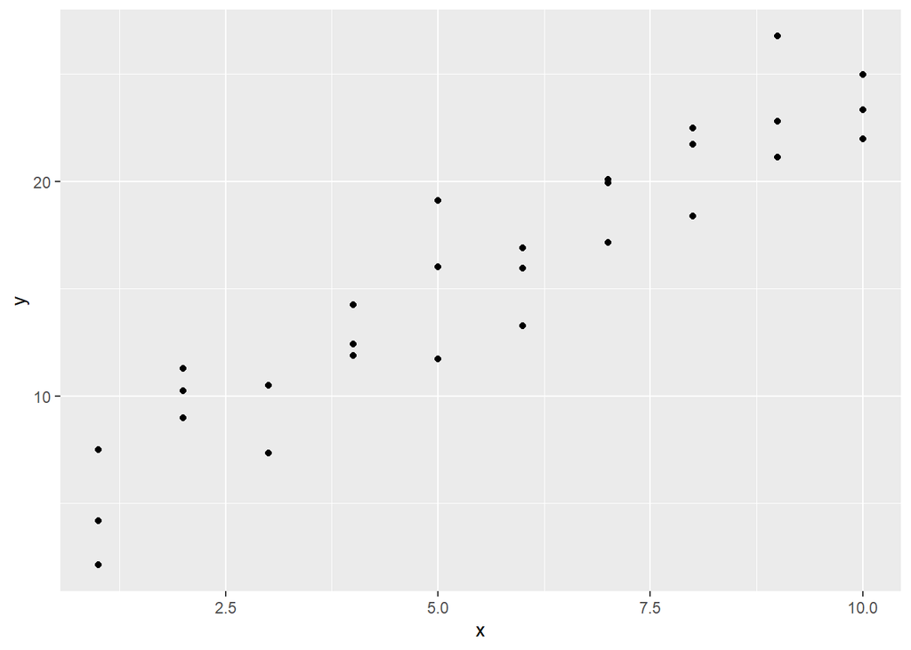

```r
library(ggplot2)
library(modelr)
# scatterplot
ggplot(sim1,aes(x,y)) + geom_point()
```

```r
# regressione

mod1 = lm(formula = y ~ x,data= sim1)
summary(mod1)
```

```
##
## Call:
## lm(formula = y ~ x, data = sim1)
##
## Residuals:
##     Min      1Q  Median      3Q     Max
## -4.1469 -1.5197  0.1331  1.4670  4.6516
##
## Coefficients:
##             Estimate Std. Error t value Pr(>|t|)
## (Intercept)   4.2208     0.8688   4.858 4.09e-05 ***
## x             2.0515     0.1400  14.651 1.17e-14 ***
## ---
## Signif. codes:  0 '***' 0.001 '**' 0.01 '*' 0.05 '.' 0.1 ' ' 1
##
## Residual standard error: 2.203 on 28 degrees of freedom
## Multiple R-squared:  0.8846, Adjusted R-squared:  0.8805
## F-statistic: 214.7 on 1 and 28 DF,  p-value: 1.173e-14
```

```r
mod1$coefficients
```

```
## (Intercept)           x
##    4.220822    2.051533
```

# VISUALIZZAZIONE

> **GRAFICO DI PREVISIONE DELL’ANDAMENTO LINEARE**

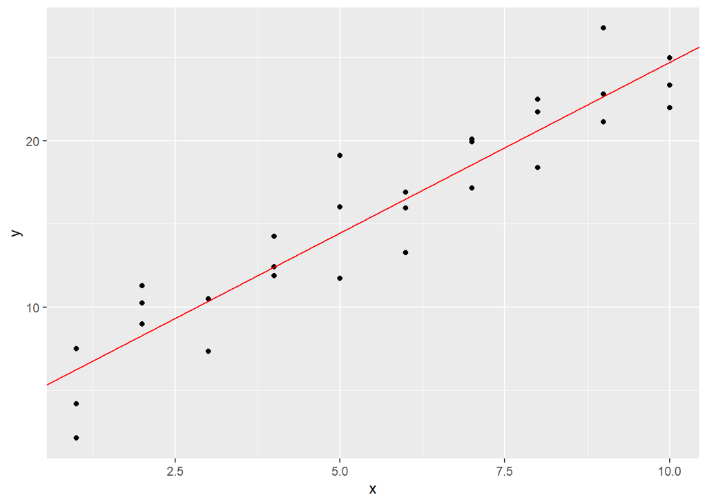

```r
ggplot(sim1,aes(x,y)) + geom_point() + geom_abline(intercept = mod1$coefficients[1], slope = mod1$coefficients[2], color = "red")
```

# COEFFICIENTE PEARSON

```r
( r = cor(sim1$x, sim1$y))
```

```
## [1] 0.9405384
```

### DETERMINAZIONE

```r
summary(mod1)$r.squared
```

```
## [1] 0.8846124
```

```r
# or
r^2
```

```
## [1] 0.8846124
```

# METODO GENERALE

```r
(grid = data_grid(sim1,x))
```

```
## # A tibble: 10 x 1
##        x
##    <int>
##  1     1
##  2     2
##  3     3
##  4     4
##  5     5
##  6     6
##  7     7
##  8     8
##  9     9
## 10    10
```

```r
# AGGIUNGE UNA PREDIZIONE DEI VALORI IN BASE AL MODELLO MOD1
(grid = add_predictions(grid,mod1))
```

```
## # A tibble: 10 x 2
##        x  pred
##    <int> <dbl>
##  1     1  6.27
##  2     2  8.32
##  3     3 10.4
##  4     4 12.4
##  5     5 14.5
##  6     6 16.5
##  7     7 18.6
##  8     8 20.6
##  9     9 22.7
## 10    10 24.7
```

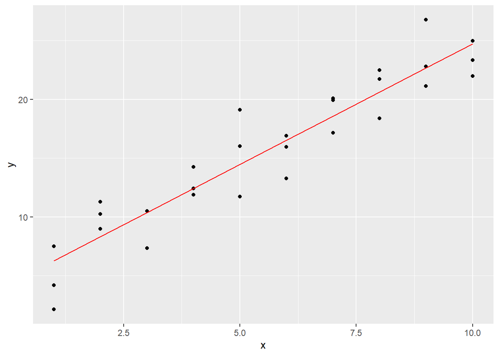

```r
ggplot(sim1, aes(x=x)) + geom_point(aes(y=y)) + geom_line(data = grid, mapping = aes(y=pred), colour = "red")
```

```r
(sim1 = add_predictions(sim1, mod1))
```

```
## # A tibble: 30 x 3
##        x     y  pred
##    <int> <dbl> <dbl>
##  1     1  4.20  6.27
##  2     1  7.51  6.27
##  3     1  2.13  6.27
##  4     2  8.99  8.32
##  5     2 10.2   8.32
##  6     2 11.3   8.32
##  7     3  7.36 10.4
##  8     3 10.5  10.4
##  9     3 10.5  10.4
## 10     4 12.4  12.4
## # ... with 20 more rows
```

```r
(sim1 = add_residuals(sim1, mod1))
```

```
## # A tibble: 30 x 4
##        x     y  pred    resid
##    <int> <dbl> <dbl>    <dbl>
##  1     1  4.20  6.27 -2.07
##  2     1  7.51  6.27  1.24
##  3     1  2.13  6.27 -4.15
##  4     2  8.99  8.32  0.665
##  5     2 10.2   8.32  1.92
##  6     2 11.3   8.32  2.97
##  7     3  7.36 10.4  -3.02
##  8     3 10.5  10.4   0.130
##  9     3 10.5  10.4   0.136
## 10     4 12.4  12.4   0.00763
## # ... with 20 more rows
```

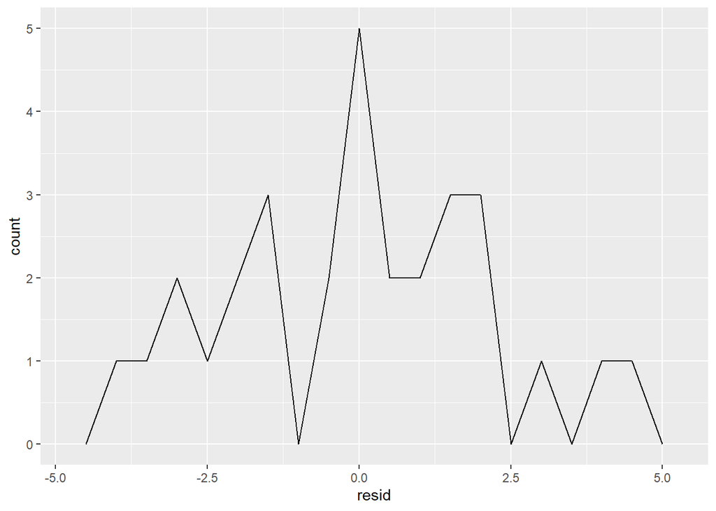

```r
# histogram of residuals (mean is always 0)
ggplot(sim1, aes(resid)) +
  geom_freqpoly(binwidth = 0.5)
```

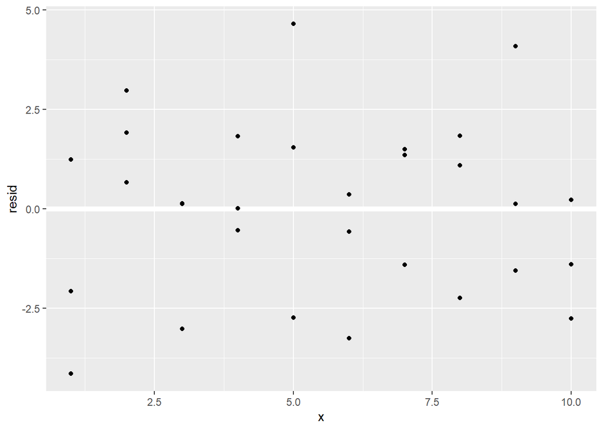

```r
# scatterplot of residuals (plot residuals as outcomes)
ggplot(sim1, aes(x, resid)) +
  geom_ref_line(h = 0) +
  geom_point()
```